# Analysis of deleted mRNAs in H1N1

```r
library(data.table)
library(reshape2)
library(ggplot2)
library(RColorBrewer)
library(dplyr)
```

# Get data

Analysing only the pathogen transcript we need to filter out cells having too few reads mapping to h1n1 genome. Take only samples where number of mapped reads on viral genome is more than 10,000 reads. 71 cells are remaining. Small insert sizes correspond to insert sizes smaller than 1000 bp. Large insert sizes correspond to insert sizes greater or equal 1000 bp. We count insert sizes only on H1N1 segments 1,2,3.

```r
isize_counts <- read.csv("data/insert_sizes_influenza_counts.csv")
dim(isize_counts)
```

```
## [1] 71  8
```

```r
head(isize_counts)
```

```
##                               sample sample_label num_small_isize
## 1 mpimg_L1185-1_Cell11_PFU24_low_S11 Cell11_PFU24           26259
## 2 mpimg_L1185-1_Cell12_PFU31_low_S12 Cell12_PFU31            2753
## 3 mpimg_L1185-1_Cell13_PFU22_low_S13 Cell13_PFU22         3199331
## 4  mpimg_L1185-1_Cell14_PFU1_low_S14  Cell14_PFU1           13567
## 5 mpimg_L1185-1_Cell15_PFU16_low_S15 Cell15_PFU16          901079
## 6  mpimg_L1185-1_Cell16_PFU3_low_S16  Cell16_PFU3          128197
##   num_large_isize        ratio PFU_class PFU DIPs
## 1              68 0.0025895883       low  24    0
## 2               2 0.0007264802       low  31    0
## 3           45254 0.0141448322       low  22    1
## 4           14300 1.0540281566       low   1    0
## 5          754342 0.8371541230       low  16    1
## 6           43516 0.3394463209       low   3    1
```

```r
sample_info <- read.csv("data/sample_info_afterQC.csv")
```

```r
# color coding for plots
PFU_class_colors <- c("#00BFC4", "#F8766D")
names(PFU_class_colors) <- c("low", "high")
isize_counts$PFU_class <- factor(isize_counts$PFU_class, levels = c("low", "high"))
table(isize_counts$PFU_class)
```

```
##
##  low high
##   40   31
```

### Compare log2 ratio of small and large insertion sizes in high vs low PFU cells

```r
# add pseudo count to ratio to avoid undefined values
w_out <- wilcox.test(log2(ratio + 1e-7) ~ PFU_class, data = isize_counts)
w_out
```

```
##
##  Wilcoxon rank sum test with continuity correction
##
## data:  log2(ratio + 1e-07) by PFU_class
## W = 831, p-value = 0.01457
## alternative hypothesis: true location shift is not equal to 0
```

```r
isize_counts$PFU_class <- factor(isize_counts$PFU_class, levels=c("low", "high"))
```

```r
w_out  <- wilcox.test(log2(ratio + 1e-7) ~ PFU_class, data = isize_counts)
```

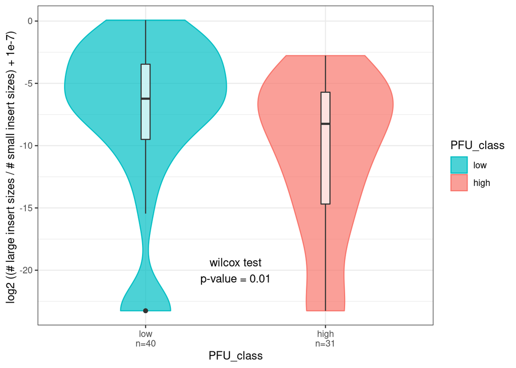

```r
nCells <- table(isize_counts$PFU_class)
xlabels <- paste0(c("low\nn=", "high\nn="), nCells)

ggplot(isize_counts, aes(PFU_class, log2(ratio + 1e-7))) +
  geom_violin(aes(fill = PFU_class, col = PFU_class), alpha = .7) +
  geom_boxplot(width = 0.05, alpha = 0.7) +
  scale_color_manual(values=PFU_class_colors) +
  scale_fill_manual(values=PFU_class_colors) +
  theme_bw() +
  ylab("log2 ((# large insert sizes / # small insert sizes) + 1e-7) ") +
  annotate("text", x = 1.5, y = -20,
           label = paste0("wilcox test\np-value = ", round(w_out$p.value,2))) +
  scale_x_discrete(labels=xlabels)
```

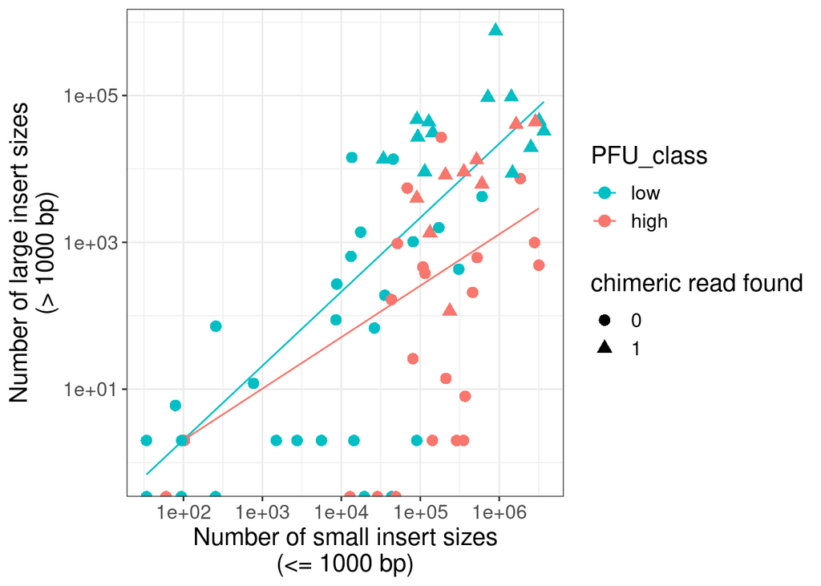

```r
# isize_counts$DIPs encodes if we could find any chimeric read in that sample
ggplot(isize_counts, aes(x=num_small_isize, y=num_large_isize)) +
  geom_smooth(method='lm', formula = y ~ x, aes(col=PFU_class), se=F, lwd=0.5) +
  geom_point(aes(col = PFU_class, shape = factor(DIPs)), size = 3) +
  scale_shape(solid = T, name="chimeric read found") +
  theme_bw()+
  scale_y_log10() +
  scale_x_log10() +
  scale_color_manual(values=PFU_class_colors) +
  ylab("Number of large insert sizes\n(> 1000 bp)") +
  xlab("Number of small insert sizes\n(<= 1000 bp)") +
  theme(text = element_text(size=15))
```

### viral mRNA content in the presence of DI RNA (any read >= 1000 bp on seg 1, 2, 3)

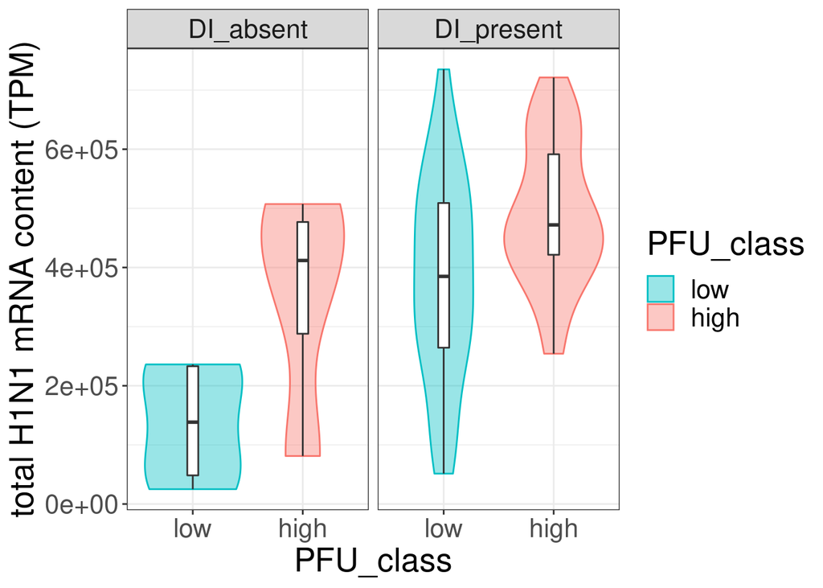

```r
dips.df <- data.frame(sample = isize_counts$sample,
                      DI_by_isize = isize_counts$num_large_isize > 0)

dips.df$DI_by_isize <- ifelse(dips.df$DI_by_isize, "DI_present", "DI_absent")

tmp <- merge(subset(sample_info, select=c(sample,
                                          PFU_class,
                                          total_H1N1)),
             dips.df, by="sample")
tmp$PFU_class <- factor(tmp$PFU_class, levels=c("low", "high"))
ggplot(tmp, aes(x = PFU_class, y = total_H1N1)) +
  geom_violin(aes(fill=PFU_class, col=PFU_class), alpha=.4) +
  geom_boxplot(width=.1) +
  scale_color_manual(values=PFU_class_colors) +
  scale_fill_manual(values=PFU_class_colors) +
  facet_grid(~ DI_by_isize, scales = "free_y") +
  theme_bw() +
  theme(text = element_text(size=20)) +
  ylab("total H1N1 mRNA content (TPM)")
```

```r
# DI present: low vs high
wilcox.test(total_H1N1 ~ PFU_class, subset(tmp, DI_by_isize == "DI_present"))
```

```
##
##  Wilcoxon rank sum test
##
## data:  total_H1N1 by PFU_class
## W = 298, p-value = 0.01275
## alternative hypothesis: true location shift is not equal to 0
```

```r
# DI absent: low vs high
wilcox.test(total_H1N1 ~ PFU_class, subset(tmp, DI_by_isize == "DI_absent"))
```

```
##
##  Wilcoxon rank sum test
##
## data:  total_H1N1 by PFU_class
## W = 3, p-value = 0.1111
## alternative hypothesis: true location shift is not equal to 0
```

```r
# high PFU cells: DI absent vs DI present
wilcox.test(total_H1N1 ~ DI_by_isize, subset(tmp, PFU_class == "high"))
```

```
##
##  Wilcoxon rank sum test
##
## data:  total_H1N1 by DI_by_isize
## W = 31, p-value = 0.1927
## alternative hypothesis: true location shift is not equal to 0
```

```r
# low PFU cells: DI absent vs DI present
wilcox.test(total_H1N1 ~ DI_by_isize, subset(tmp, PFU_class == "low"))
```

```
##
##  Wilcoxon rank sum test
##
## data:  total_H1N1 by DI_by_isize
## W = 16, p-value = 0.001547
## alternative hypothesis: true location shift is not equal to 0
```

```r
### sample sizes in groups
aggregate(sample ~ PFU_class + DI_by_isize, tmp , length)
```

```
##   PFU_class DI_by_isize sample
## 1       low   DI_absent      5
## 2      high   DI_absent      4
## 3       low  DI_present     35
## 4      high  DI_present     27
```

# Chimeric reads to detect the deleted region

### Loading the data

Data contains parsed information (obtained by STAR) about chimeric junctions detected in H1N1 pre infection (seed virion), in H1N1 post infection (progeny virion) and H1N1 post infection in single cells.

```r
chim_dat <- fread("data/chim_junctions_h1n1.csv")
head(chim_dat)
```

```
##      chr_don chr_don_start chr_don_str   chr_acc chr_acc_start chr_acc_str
## 1: H1N1_seg3      630/1860         +/- H1N1_seg3      1860/630         +/-
## 2: H1N1_seg3      424/1691         +/- H1N1_seg3      1690/425         +/-
## 3: H1N1_seg3      463/1743         +/- H1N1_seg3      1740/466         +/-
## 4: H1N1_seg1      378/1792         +/- H1N1_seg1      1789/381         +/-
## 5: H1N1_seg3      313/1853         +/- H1N1_seg3      1852/314         +/-
## 6: H1N1_seg2      310/1859         +/- H1N1_seg2      1859/310         +/-
##    num_reads distance       cpm infection                   junctions
## 1:        30     1231 1.0539676       pre H1N1_seg3:630/1860-1860/630
## 2:        17     1267 0.5972483       pre H1N1_seg3:424/1691-1690/425
## 3:        75     1278 2.6349190       pre H1N1_seg3:463/1743-1740/466
## 4:        17     1412 0.5972483       pre H1N1_seg1:378/1792-1789/381
## 5:        23     1540 0.8080418       pre H1N1_seg3:313/1853-1852/314
## 6:        35     1550 1.2296289       pre H1N1_seg2:310/1859-1859/310
##    num_sample
## 1:          1
## 2:          1
## 3:          1
## 4:          1
## 5:          1
## 6:          1
```

Please note: Locus of chimeric junctions can vary by a few base pairs Example: H1N1_seg3:351/1905 (+) and H1N1_seg3:1907/353 (-) are the same. Split locus cannot be assigned unambiguously since end fragment of first part is equal to start fragment of second part of the split read: GAAACCAAAGTTTCTACCAGATTT_GT_ […] _GT_GGAGGAAAGTTCCATTGGGA (reference) GAAACCAAAGTTTCTACCAGATTT/GT/GGAGGAAAGTTCCATTGGGAAGGTC (read)

```r
chim_dat$infection <- factor(chim_dat$infection, levels = c("pre", "post", "post_sc"))
table(chim_dat$infection)
```

```
##
##     pre    post post_sc
##      16     141      19
```

We observe 16 different DI vRNAs before infection in the seed virus, 141 different DI vRNAs (16 overlapping with the seed virion) were found in the progeny virions and 19 different DI vRNAs in single cells.

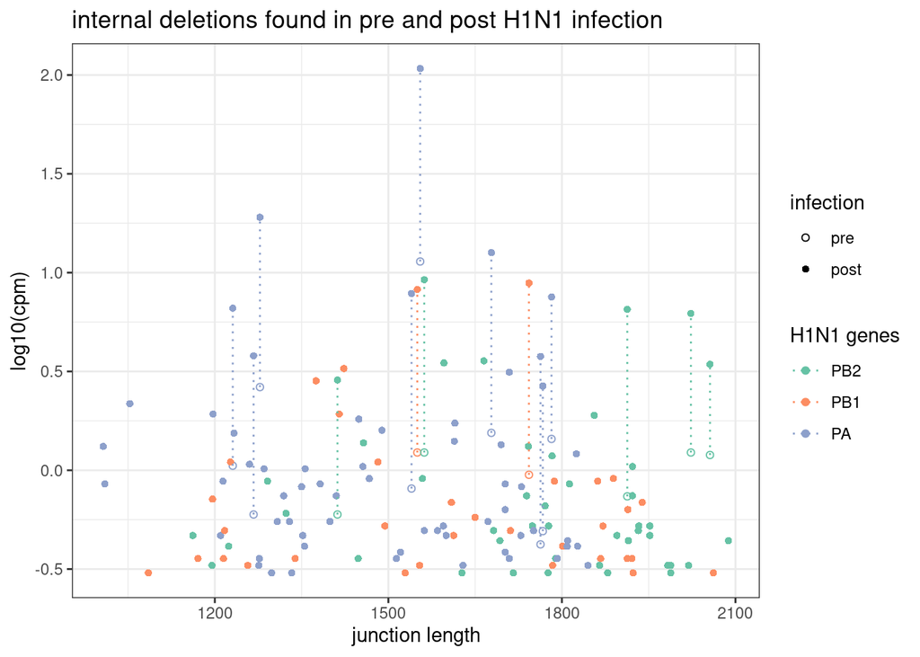

```r
# subset for only pre and post infection samples (bulk) and H1N1_seg1/2/3
ggplot(subset(chim_dat, chr_don != "H1N1_seg4" & infection %in% c("pre", "post")),
       aes(distance, log10(cpm), col=chr_don, shape= infection, group = junctions)) +
  geom_point() +
  geom_line(linetype = "dotted") +
  scale_shape_manual(values = c(1, 16)) +
  scale_color_brewer(palette="Set2", name="H1N1 genes", labels=c("PB2", "PB1", "PA")) +
  theme_bw() +
  xlab("junction length") +
  ggtitle("internal deletions found in pre and post H1N1 infection") # +
```

```r
h1n1_segment_info <- data.frame(chr = c("H1N1_seg1",
                                        "H1N1_seg2",
                                        "H1N1_seg3",
                                        "H1N1_seg4",
                                        "H1N1_seg5",
                                        "H1N1_seg6",
                                        "H1N1_seg7",
                                        "H1N1_seg8"),
                                length = c(2341,
                                           2341,
                                           2233,
                                           1778,
                                           1565,
                                           1413,
                                           1027,
                                           890))
```

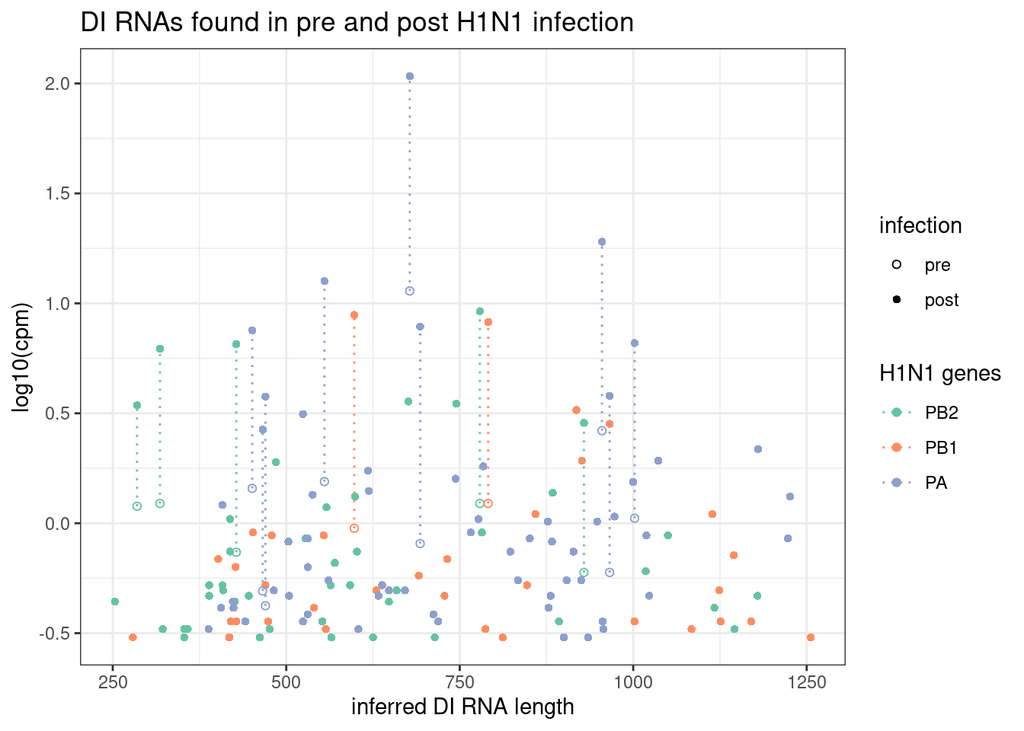

```r
chim_dat <- merge(chim_dat, h1n1_segment_info, by.x="chr_don", by.y="chr")
chim_dat$DI_length   <- chim_dat$length - chim_dat$distance

ggplot(subset(chim_dat, chr_don != "H1N1_seg4" & infection %in% c("pre", "post")),
       aes(DI_length, log10(cpm), col=chr_don, shape= infection, group = junctions)) +
  geom_point() +
  geom_line(linetype = "dotted") +
  scale_shape_manual(values = c(1, 16)) +
  scale_color_brewer(palette="Set2", name="H1N1 genes", labels=c("PB2", "PB1", "PA")) +
  theme_bw() +
  xlab("inferred DI RNA length") +
  ggtitle("DI RNAs found in pre and post H1N1 infection")
```

### Visualise breaking points on H1N1 segments

```r
source("scripts/process_chimeric_information.R")
### parsing the junctions to get start and end points
all_junctions_df <- data.frame()

for (inf in levels(chim_dat$infection)) {
  sub <- subset(chim_dat, subset = infection == inf)
  df  <- split_junctions(sub$junctions)
  df$infection <- inf

  all_junctions_df <- rbind(all_junctions_df, df)
}
```

```r
h1n1_segment123 <- subset(h1n1_segment_info, grepl("seg[123]", h1n1_segment_info$chr))

dummy <- data.frame(start = h1n1_segment123$length, value = 0,
                    chr = h1n1_segment123$chr,
                    infection = "pre", stringsAsFactors=FALSE)

junctions123 <- subset(all_junctions_df, grepl("seg[123]", all_junctions_df$chr))

# mask duplicated entries
junctions123$dup <- F
junctions123$dup[duplicated(paste0(junctions123$junction_merged,
                                   junctions123$infection))] <- T
```

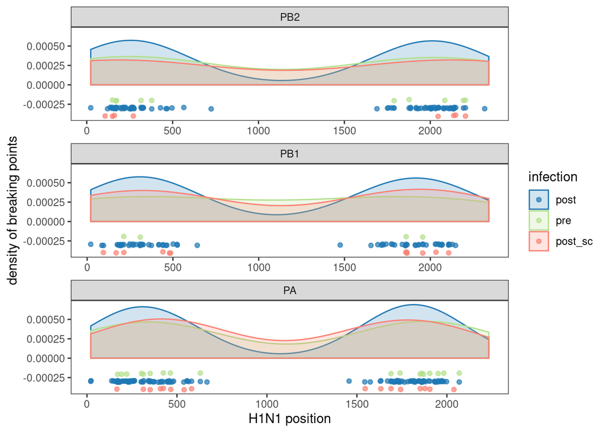

```r
### removing the duplicated entries
junctions123_t <- subset(junctions123, !junctions123$dup)
junctions123_t <- subset(junctions123_t, select=-dup)
junctions123_t <- melt(junctions123_t, id.vars = c("chr", "junction_merged", "infection"))

junctions123_t$y <- ifelse(junctions123_t$infection == "pre", -2e-4,
                           ifelse(junctions123_t$infection == "post",
                                  -3e-4,
                                  -4e-4))
junctions123_t$infection <- factor(junctions123_t$infection,
                                   levels=c("post", "pre", "post_sc"))

h1n1_genes <- list("H1N1_seg1" = "PB2",
                   "H1N1_seg2" = "PB1",
                   "H1N1_seg3" = "PA")

h1n1_labeller <- function(variable, value) { return(h1n1_genes[value]) }

ggplot(junctions123_t, aes(x=value, y=..density.., col=infection, fill = infection)) +
  geom_jitter(aes(x=value, y=y, col=infection), height = 0.00001, alpha =.7) +
  geom_density(alpha=0.2) +
  geom_blank(aes(x=start, y =0), data=dummy) +
  facet_wrap( ~ chr, ncol= 1, scales = "free_x", labeller = h1n1_labeller) +
  theme_bw() +
  scale_color_manual(values = c("#1f78b4", "#b2df8a", "#fb8072")) +
  scale_fill_manual(values = c("#1f78b4", "#b2df8a", "#fb8072")) +
  theme(panel.grid.major.y = element_line( size=0, color=NULL ),
        panel.grid.minor.y = element_line( size=0, color=NULL ),
        panel.grid.major.x = element_line( size=0, color=NULL ),
        panel.grid.minor.x = element_line( size=0, color=NULL )) +
  xlab("H1N1 position") +
  ylab("density of breaking points")
```